# CMSC320

# Final Tutorial Project

## "Top 1000 Twitch Streamers"

## Data Collection and Parsing

Twitch is a live streaming service that is mainly used for video game streaming, but also for other forms of entertainment and creative content. It was launched in 2011 and has since become one of the most popular streaming platforms, with millions of daily active users. People can watch live streams, interact with other users and streamers, donate to their favorite content creators to support their work, and discover new and exciting content. Through this tutorial, we can explore and analyze data about Twitch and its users.

First, we pulled data from [this dataset on Kaggle](https://www.kaggle.com/datasets/aayushmishra1512/twitchdata?resource=download) on the top 1000 Twitch streamers (based on watch time) from a specific year. This dataset includes information on each of the listed streamers, such as number of followers, followers gained over the past year, and total watch time in minutes.

First, we must import several Python packages that will allow us to wrangle and visualize the data.

[requests](https://requests.readthedocs.io/en/latest/api/): send HTTP requests [pandas](https://pandas.pydata.org/docs/): manipulate and analyze data using dataframes [numpy](https://numpy.org/doc/stable/reference/index.html): perform operations on large, multidimensional arrays and matrices [matplotlib](https://matplotlib.org/stable/api/index): visualize data through graphs and charts [seaborn](https://seaborn.pydata.org/api.html): (based on matplotlib) also create graphics of statistical information

We downloaded the .csv file containing the dataset and uploaded it to our Jupyter folder. Then, using the pandas software library, the data within the csv file is put into a dataframe using the function "read_csv". This will allow us to perform various functions that will help us analyze the data. Thankfully, the data is already well organized in a .csv file, so there is no need to do any extra collection or parsing.

```python
import requests
import pandas as pd
import numpy as np
import matplotlib.pyplot as plt
import seaborn as sns

df = pd.read_csv("twitchdata-update.csv")
df
```

|  | Channel | Watch time(Minutes) | Stream time(minutes) | Peak viewers | Average viewers | Followers | Followers gained | Views gained | Partnered | Mature | Language |
| --- | --- | --- | --- | --- | --- | --- | --- | --- | --- | --- | --- |
| 0 | xQcOW | 6196161750 | 215250 | 222720 | 27716 | 3246298 | 1734810 | 93036735 | True | False | English |
| 1 | summit1g | 6091677300 | 211845 | 310998 | 25610 | 5310163 | 1370184 | 89705964 | True | False | English |
| 2 | Gaules | 5644590915 | 515280 | 387315 | 10976 | 1767635 | 1023779 | 102611607 | True | True | Portuguese |
| 3 | ESL_CSGO | 3970318140 | 517740 | 300575 | 7714 | 3944850 | 703986 | 106546942 | True | False | English |
| 4 | Tfue | 3671000070 | 123660 | 285644 | 29602 | 8938903 | 2068424 | 78998587 | True | False | English |
| ... | ... | ... | ... | ... | ... | ... | ... | ... | ... | ... | ... |
| 995 | LITkillah | 122524635 | 13560 | 21359 | 9104 | 601927 | 562691 | 2162107 | True | False | Spanish |
| 996 | 빅헤드 (bighead033) | 122523705 | 153000 | 3940 | 793 | 213212 | 52289 | 4399897 | True | False | Korean |
| 997 | 마스카 (newmasca) | 122452320 | 217410 | 6431 | 567 | 109068 | -4942 | 3417970 | True | False | Korean |
| 998 | AndyMilonakis | 122311065 | 104745 | 10543 | 1153 | 547446 | 109111 | 3926918 | True | False | English |
| 999 | Remx | 122192850 | 99180 | 13788 | 1205 | 178553 | 59432 | 2049420 | True | False | French |

1000 rows × 11 columns

## Data Management/Representation

### Cleaning Data

Data cleaning is incredibly important when handling datasets. It helps to ensure that the data being used is accurate and usable, as even small errors can greatly impact the results. Tasks to clean data include identifying and correcting errors, dealing with missing values, and standardizing formats. We can clean the data by dropping any rows (using pandas dropna function) that had NaN or None values, since they are inconsistent with the rest of the data. After executing the dropna function, we can see that there were no rows with NaN or None values, so the data set was already sufficiently cleaned.

```python
df = df.dropna()
df
```

|  | Channel | Watch time(Minutes) | Stream time(minutes) | Peak viewers | Average viewers | Followers | Followers gained | Views gained | Partnered | Mature | Language |
| --- | --- | --- | --- | --- | --- | --- | --- | --- | --- | --- | --- |
| 0 | xQcOW | 6196161750 | 215250 | 222720 | 27716 | 3246298 | 1734810 | 93036735 | True | False | English |
| 1 | summit1g | 6091677300 | 211845 | 310998 | 25610 | 5310163 | 1370184 | 89705964 | True | False | English |
| 2 | Gaules | 5644590915 | 515280 | 387315 | 10976 | 1767635 | 1023779 | 102611607 | True | True | Portuguese |
| 3 | ESL_CSGO | 3970318140 | 517740 | 300575 | 7714 | 3944850 | 703986 | 106546942 | True | False | English |
| 4 | Tfue | 3671000070 | 123660 | 285644 | 29602 | 8938903 | 2068424 | 78998587 | True | False | English |
| ... | ... | ... | ... | ... | ... | ... | ... | ... | ... | ... | ... |
| 995 | LITkillah | 122524635 | 13560 | 21359 | 9104 | 601927 | 562691 | 2162107 | True | False | Spanish |
| 996 | 빅헤드 (bighead033) | 122523705 | 153000 | 3940 | 793 | 213212 | 52289 | 4399897 | True | False | Korean |
| 997 | 마스카 (newmasca) | 122452320 | 217410 | 6431 | 567 | 109068 | -4942 | 3417970 | True | False | Korean |
| 998 | AndyMilonakis | 122311065 | 104745 | 10543 | 1153 | 547446 | 109111 | 3926918 | True | False | English |
| 999 | Remx | 122192850 | 99180 | 13788 | 1205 | 178553 | 59432 | 2049420 | True | False | French |

1000 rows × 11 columns

Here, we renamed the columns in snake case (replacing spaces with underscores to make each column name one word) in order to avoid issues with accessing columns by their names.

```python
df.columns = ['channel', 'watch_time', 'stream_time', 'peak_viewers', 'avg_viewers', 'followers', 'followers_gained', 'views_gained', 'partnered', 'mature', 'language']
df
```

|  | channel | watch_time | stream_time | peak_viewers | avg_viewers | followers | followers_gained | views_gained | partnered | mature | language |
| --- | --- | --- | --- | --- | --- | --- | --- | --- | --- | --- | --- |
| 0 | xQcOW | 6196161750 | 215250 | 222720 | 27716 | 3246298 | 1734810 | 93036735 | True | False | English |
| 1 | summit1g | 6091677300 | 211845 | 310998 | 25610 | 5310163 | 1370184 | 89705964 | True | False | English |
| 2 | Gaules | 5644590915 | 515280 | 387315 | 10976 | 1767635 | 1023779 | 102611607 | True | True | Portuguese |
| 3 | ESL_CSGO | 3970318140 | 517740 | 300575 | 7714 | 3944850 | 703986 | 106546942 | True | False | English |
| 4 | Tfue | 3671000070 | 123660 | 285644 | 29602 | 8938903 | 2068424 | 78998587 | True | False | English |
| ... | ... | ... | ... | ... | ... | ... | ... | ... | ... | ... | ... |
| 995 | LITkillah | 122524635 | 13560 | 21359 | 9104 | 601927 | 562691 | 2162107 | True | False | Spanish |
| 996 | 빅헤드 (bighead033) | 122523705 | 153000 | 3940 | 793 | 213212 | 52289 | 4399897 | True | False | Korean |
| 997 | 마스카 (newmasca) | 122452320 | 217410 | 6431 | 567 | 109068 | -4942 | 3417970 | True | False | Korean |
| 998 | AndyMilonakis | 122311065 | 104745 | 10543 | 1153 | 547446 | 109111 | 3926918 | True | False | English |
| 999 | Remx | 122192850 | 99180 | 13788 | 1205 | 178553 | 59432 | 2049420 | True | False | French |

1000 rows × 11 columns

When we analyze the data, the streamers’ rankings within the top 1000 may be helpful to draw statistical information from. We can create a new column that holds the rank for each of the content creators by using the “reset_index” pandas function. This resets the index to 0 and we can copy each index value into the rows. Then, we can add 1 to every entry so that the #1 streamer starts at rank 1 instead of 0.

```python
df.reset_index(inplace=True)
df.rename(columns={'index':'ranking'}, inplace=True)
df['ranking'] = df['ranking'] + 1
df
```

|  | ranking | channel | watch_time | stream_time | peak_viewers | avg_viewers | followers | followers_gained | views_gained | partnered | mature | language |
| --- | --- | --- | --- | --- | --- | --- | --- | --- | --- | --- | --- | --- |
| 0 | 1 | xQcOW | 6196161750 | 215250 | 222720 | 27716 | 3246298 | 1734810 | 93036735 | True | False | English |
| 1 | 2 | summit1g | 6091677300 | 211845 | 310998 | 25610 | 5310163 | 1370184 | 89705964 | True | False | English |
| 2 | 3 | Gaules | 5644590915 | 515280 | 387315 | 10976 | 1767635 | 1023779 | 102611607 | True | True | Portuguese |
| 3 | 4 | ESL_CSGO | 3970318140 | 517740 | 300575 | 7714 | 3944850 | 703986 | 106546942 | True | False | English |
| 4 | 5 | Tfue | 3671000070 | 123660 | 285644 | 29602 | 8938903 | 2068424 | 78998587 | True | False | English |
| ... | ... | ... | ... | ... | ... | ... | ... | ... | ... | ... | ... | ... |
| 995 | 996 | LITkillah | 122524635 | 13560 | 21359 | 9104 | 601927 | 562691 | 2162107 | True | False | Spanish |
| 996 | 997 | 빅헤드 (bighead033) | 122523705 | 153000 | 3940 | 793 | 213212 | 52289 | 4399897 | True | False | Korean |
| 997 | 998 | 마스카 (newmasca) | 122452320 | 217410 | 6431 | 567 | 109068 | -4942 | 3417970 | True | False | Korean |
| 998 | 999 | AndyMilonakis | 122311065 | 104745 | 10543 | 1153 | 547446 | 109111 | 3926918 | True | False | English |
| 999 | 1000 | Remx | 122192850 | 99180 | 13788 | 1205 | 178553 | 59432 | 2049420 | True | False | French |

1000 rows × 12 columns

## Exploratory Data Analysis

### What is exploratory data analysis

Exploratory data analysis is a way of analyzing and understanding data that focuses on identifying patterns, trends, and relationships in the data. It involves the use of statistical graphics and other visualizations. We can explore the data now, as we have finished cleaning and tidying.

First, let’s explore how watch time (in minutes) is distributed amongst the streamers by rank, as this dataset is based on watch time. We can use matplotlib functions to create a bar plot that displays how much watch time each of the top 1000 streamers get.

[figure not shown]

```python
# Set the figure size and label font sizes
# This will make the chart easier to read
plt.figure(figsize=(15,15))
plt.rc('ytick', labelsize=20)
plt.rc('axes', labelsize=25)
sns.barplot(x = "ranking", y = "watch_time", data = df).set(title="Channel Count by Language")
plt.xticks([])
plt.show()
```

The graph above shows the streamers’ ranking on the x-axis and the watch time in minutes on the y-axis. As shown, higher ranked streamers have exponentially more watch time than lower ranked streamers. The bar plot shows that the relationship between watch time and streamer rank is an exponential decay function, as the watch time for each streamer decreases proportionally to the previous.

### Looking at data based on categories

Another way to learn other information about this dataset is splitting the data into categories. Let’s use the “groupby” pandas function to split the data into groups based on language.

```python
grouped_by_language = df.groupby("language")
grouped_by_language.first()
```

| language | ranking | channel | watch_time | stream_time | peak_viewers | avg_viewers | followers | followers_gained | views_gained | partnered | mature |
| --- | --- | --- | --- | --- | --- | --- | --- | --- | --- | --- | --- |
| Arabic | 280 | shongxbong | 400635750 | 50310 | 94869 | 7656 | 845158 | 671127 | 4198232 | True | False |
| Chinese | 111 | uzra | 812362125 | 208785 | 14181 | 3683 | 185506 | 29752 | 20715640 | True | False |
| Czech | 117 | Agraelus | 779867430 | 169515 | 23555 | 4642 | 414951 | 132125 | 20334558 | True | True |
| English | 1 | xQcOW | 6196161750 | 215250 | 222720 | 27716 | 3246298 | 1734810 | 93036735 | True | False |
| Finnish | 552 | OfficialAndyPyro | 215726910 | 209625 | 9676 | 1027 | 255595 | 29422 | 10284627 | True | True |
| French | 31 | Solary | 1546597380 | 486510 | 24470 | 3187 | 493207 | 143569 | 48799554 | True | False |
| German | 16 | MontanaBlack88 | 2408460990 | 67740 | 181600 | 33514 | 2911316 | 1101093 | 37189666 | True | True |
| Greek | 514 | Pun1shers_TV | 230552955 | 123345 | 6289 | 1961 | 82289 | 51159 | 4148542 | True | False |
| Hungarian | 450 | KriszhAdvice | 258011790 | 147675 | 28709 | 1593 | 284899 | 97984 | 6927865 | True | False |
| Italian | 125 | POW3Rtv | 721548885 | 177885 | 69009 | 3836 | 1080764 | 495072 | 23271722 | True | False |
| Japanese | 69 | fps_shaka | 1131509385 | 215160 | 26572 | 5195 | 303671 | 128907 | 21331882 | True | False |
| Korean | 18 | 풍월량 (hanryang1125) | 2186662470 | 181230 | 26999 | 12201 | 494445 | 92205 | 34405975 | True | False |
| Other | 384 | LigaPro1 | 298828170 | 232620 | 11533 | 1149 | 30986 | 29434 | 60922719 | False | False |
| Polish | 126 | IzakOOO | 717096330 | 129165 | 43050 | 4463 | 1461767 | 286467 | 23586902 | True | False |
| Portuguese | 3 | Gaules | 5644590915 | 515280 | 387315 | 10976 | 1767635 | 1023779 | 102611607 | True | True |
| Russian | 37 | Evelone192 | 1474742220 | 83010 | 106900 | 16422 | 1075101 | 826433 | 47400543 | True | False |
| Slovak | 378 | resttpowered | 304222200 | 148335 | 9248 | 2072 | 252184 | 37681 | 8585834 | True | False |
| Spanish | 14 | Rubius | 2588632635 | 58275 | 240096 | 42948 | 5751354 | 3820532 | 58599449 | True | False |
| Swedish | 923 | CyrusTWO | 131621775 | 128085 | 2727 | 1027 | 96691 | 25277 | 5787660 | True | True |
| Thai | 192 | RebirthzTV | 548041425 | 118920 | 14578 | 4629 | 276694 | 76546 | 8434367 | True | False |
| Turkish | 122 | Elraenn | 726379485 | 51150 | 65543 | 13224 | 1223076 | 672978 | 20881140 | True | False |

This retrieves the first entry for each language, so it provides us with a list of languages that the top 1000 streamers speak. We can use Python’s count function to see how many top streamers speak each of those languages.

```python
channel_count_by_language = grouped_by_language["channel"].count()
channel_count_by_language
```

```
language
Arabic          5
Chinese        30
Czech           6
English       485
Finnish         1
French         66
German         49
Greek           1
Hungarian       2
Italian        17
Japanese       10
Korean         77
Other           1
Polish         12
Portuguese     61
Russian        74
Slovak          1
Spanish        68
Swedish         1
Thai           11
Turkish        22
Name: channel, dtype: int64
```

Next, we can sort by descending order so we can figure out how much each language is represented amongst the top streamers.

```python
channel_count_by_language = channel_count_by_language.sort_values(ascending=False)
channel_count_by_language
```

```
language
English       485
Korean         77
Russian        74
Spanish        68
French         66
Portuguese     61
German         49
Chinese        30
Turkish        22
Italian        17
Polish         12
Thai           11
Japanese       10
Czech           6
Arabic          5
Hungarian       2
Other           1
Greek           1
Slovak          1
Finnish         1
Swedish         1
Name: channel, dtype: int64
```

As shown in the series above, English is the most represented language out of this list; nearly half of the top 1000 streamers are English speakers. It is followed by Korean as the second most represented, and Russian as the third. We can visualize this information by creating a bar graph using the matplotlib library. However, we must first tidy the data by converting channel_count_by_language into a dataframe (using “to_frame” pandas function) and reset the index. The languages were in the index, so this will put them in a column instead.

```python
channel_count_by_language_df = channel_count_by_language.to_frame()
channel_count_by_language_df.reset_index(inplace=True)
channel_count_by_language_df.columns = ['language', 'channel_count']
```

Next, we can use a Seaborn barplot to visualize the channel count by language.

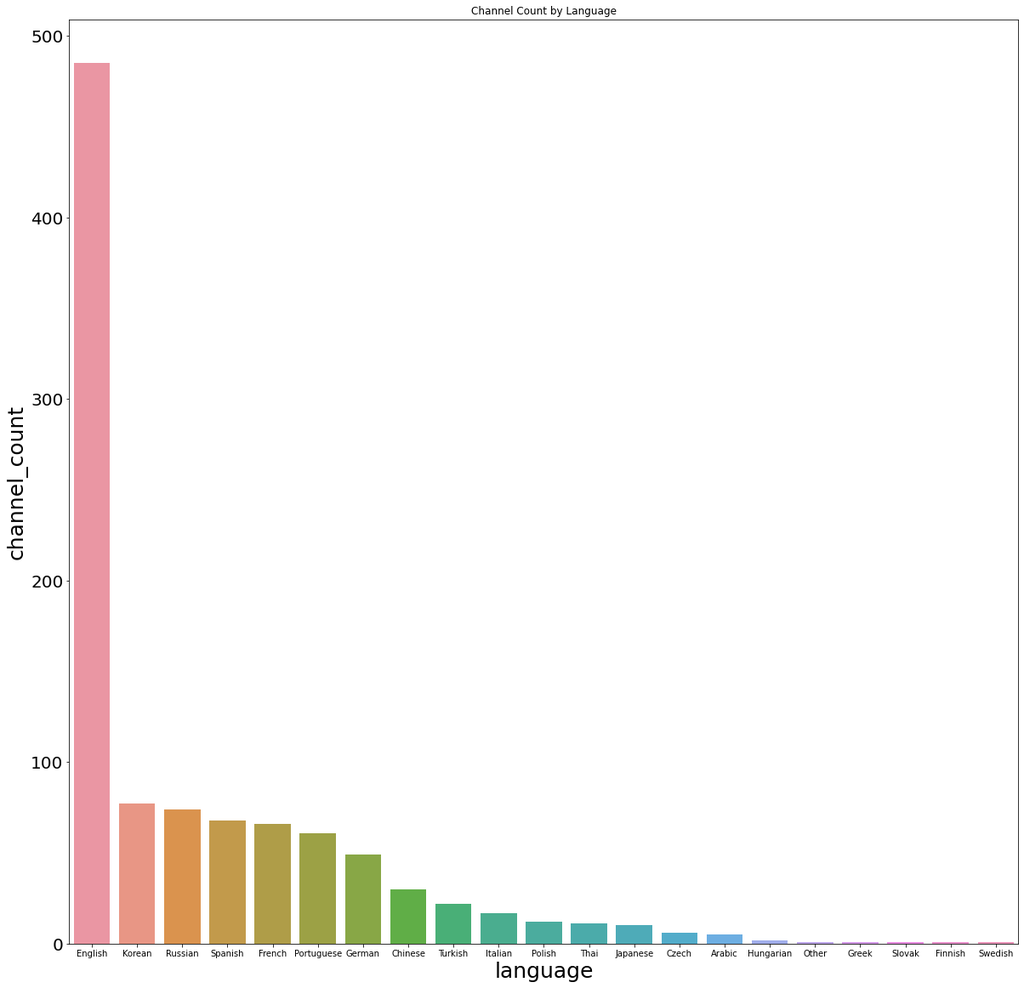

```python
# Set the figure size and label font sizes
# This is especially important when we have a lot of information on the x-axis
plt.figure(figsize=(20,20))
plt.rc('xtick', labelsize=10)
plt.rc('ytick', labelsize=20)
plt.rc('axes', labelsize=25)
sns.barplot(x = "language", y = "channel_count", data = channel_count_by_language_df).set(title="Channel Count by Language")
plt.show()
```

As you can see from the bar plot, the top 1000 channels on Twitch are overwhelmingly in the English language. There are over 6 times as many English-speaking channels in the top 1000 than Korean-speaking channels, even though Korean is the second most used language for the top streamers.

Let’s create another visualization of data from this set. We can try grouping the channels by Maturity rating.

```python
grouped_by_maturity = df.groupby("mature")
channel_count_by_maturity = grouped_by_maturity["channel"].count()
channel_count_by_maturity
```

```
mature
False    770
True     230
Name: channel, dtype: int64
```

```
Not Mature: 77.0%
Mature: 23.0%
```

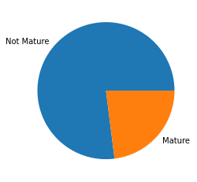

```python
print("Not Mature: " + str(770 / (1000) * 100) + "%")
print("Mature: " + str(230 / (1000) * 100) + "%")
# We use a matplotlib pie chart to visualize this data in a simple way
plt.pie(channel_count_by_maturity, labels = ['Not Mature', 'Mature'])
plt.show()
```

By looking at the results of this pie chart, we can see that most of the top 1000 streamers do not have their channels marked as “mature.” This maturity flag is a setting that the content creator can turn on or off, so this chart shows that the top 1000 streamers tend to run non-mature pages. Let’s use the same approach to see how many streamers are partnered with Twitch.

```python
grouped_by_partner = df.groupby("partnered")
channel_count_by_partner = grouped_by_partner["channel"].count()
channel_count_by_partner
```

```
partnered
False     22
True     978
Name: channel, dtype: int64
```

```
Not Partnered: 2.1999999999999997%
Partnered: 97.8%
```

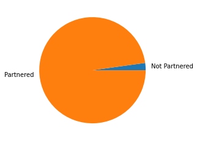

```python
print("Not Partnered: " + str(22 / (1000) * 100) + "%")
print("Partnered: " + str(978 / (1000) * 100) + "%")
# We use a matplotlib pie chart to visualize this data in a simple way
plt.pie(channel_count_by_partner, labels = ['Not Partnered', 'Partnered'])
plt.show()
```

The vast majority of the top 1000 are partnered with Twitch, with only a mere 2.1997% of them not having a partnership with Twitch.

### Streaming Times vs Followers Gained

Next, let’s see if there is any correlation between how much and how often a streamer was live, and the number of followers they gained over the course of one year. This might be useful information for content creators (that want to grow their channel) to know because it may help them figure out how to get the most followers with the most optimal streaming time. To start this process, let’s clean up the data so that we can only see the channel names, amount of time spent streaming in minutes, and the amount of followers gained over the year that this data was collected. We can use df.filter (from pandas library) to create a new dataframe that holds only those specific columns and filters the rest of them out.

```python
# df.filter is used to create a new dataframe where only the columns we specify are present.
streaming_followers_gained_df = df.filter(['channel', 'stream_time', 'followers_gained'])
streaming_followers_gained_df
```

|  | channel | stream_time | followers_gained |
| --- | --- | --- | --- |
| 0 | xQcOW | 215250 | 1734810 |
| 1 | summit1g | 211845 | 1370184 |
| 2 | Gaules | 515280 | 1023779 |
| 3 | ESL_CSGO | 517740 | 703986 |
| 4 | Tfue | 123660 | 2068424 |
| ... | ... | ... | ... |
| 995 | LITkillah | 13560 | 562691 |
| 996 | 빅헤드 (bighead033) | 153000 | 52289 |
| 997 | 마스카 (newmasca) | 217410 | -4942 |
| 998 | AndyMilonakis | 104745 | 109111 |
| 999 | Remx | 99180 | 59432 |

1000 rows × 3 columns

Scatter plots are a great way to determine whether or not there is a correlation between two variables. For our dataset, we can use seaborn library functions to create a scatter plot to compare the time spent streaming vs. the number of followers gained over a year, for each streamer in the list.

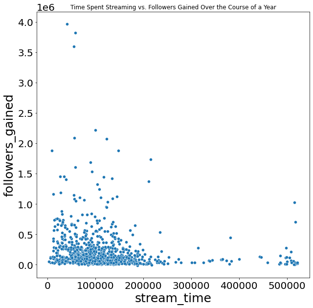

```python
# This function clears the previous plot.
plt.clf()
plt.figure(figsize=(10,10))
plt.rc('xtick', labelsize=20)
plt.rc('ytick', labelsize=20)
plt.rc('axes', labelsize=25)
sns.scatterplot(x = "stream_time", y = "followers_gained", data = streaming_followers_gained_df).set(title="Time Spent Streaming vs. Followers Gained Over the Course of a Year")
plt.show()
```

As you can see in this visualization, this dataset has many outliers where some are extremely outlying. From looking at this scatter plot, we might assume that there is not a very strong correlation between the two variables. We can figure out more about this by using linear regression later in the next section of this tutorial.

### Watch Time vs Followers

```python
watch_followers_df = df.filter(['channel', 'watch_time', 'followers_gained'])
watch_followers_df
```

|  | channel | watch_time | followers_gained |
| --- | --- | --- | --- |
| 0 | xQcOW | 6196161750 | 1734810 |
| 1 | summit1g | 6091677300 | 1370184 |
| 2 | Gaules | 5644590915 | 1023779 |
| 3 | ESL_CSGO | 3970318140 | 703986 |
| 4 | Tfue | 3671000070 | 2068424 |
| ... | ... | ... | ... |
| 995 | LITkillah | 122524635 | 562691 |
| 996 | 빅헤드 (bighead033) | 122523705 | 52289 |
| 997 | 마스카 (newmasca) | 122452320 | -4942 |
| 998 | AndyMilonakis | 122311065 | 109111 |
| 999 | Remx | 122192850 | 59432 |

1000 rows × 3 columns

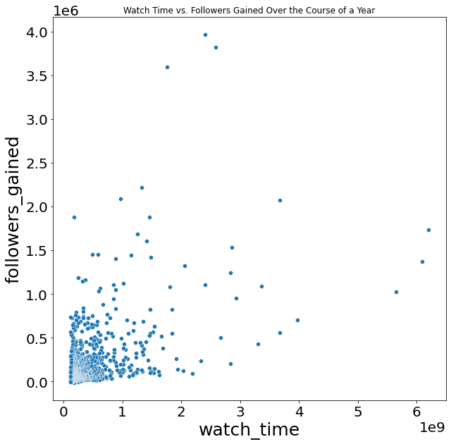

```python
plt.clf()
plt.figure(figsize=(10,10))
plt.rc('xtick', labelsize=20)
plt.rc('ytick', labelsize=20)
plt.rc('axes', labelsize=25)
sns.scatterplot(x = "watch_time", y = "followers_gained", data = watch_followers_df).set(title="Watch Time vs. Followers Gained Over the Course of a Year")
plt.show()
```

There are also a lot of outliers here and there might be some correlation.

## Hypothesis Testing

The [null hypothesis](https://towardsdatascience.com/hypothesis-testing-for-data-scientists-everything-you-need-to-know-8c36ddde4cd2) is a statement that claims that there is no effect or association between two variables. It is important to use when testing the significance of differences in experiments or observations.

### Streaming Times vs Followers Gained

Our null hypothesis is that there is no relationship between the amount of time that a streamer streams and the number of followers gained. We can explore this through seaborn’s regplot function, where it will plot data and a linear regression model fit.

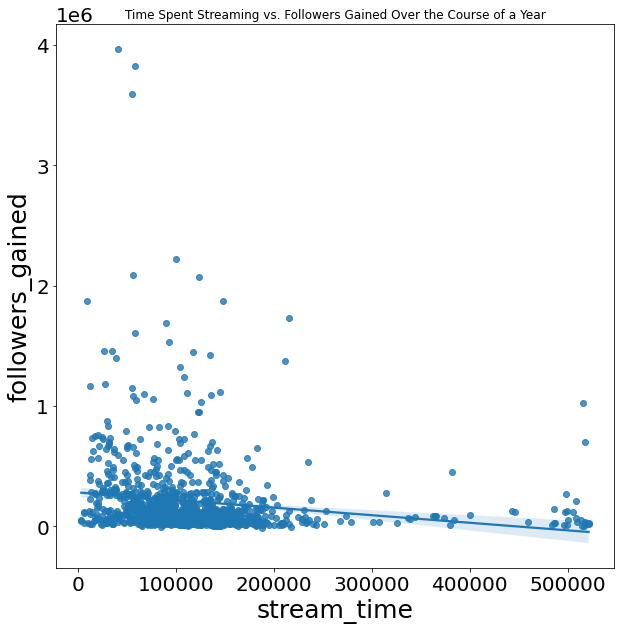

```python
plt.figure(figsize=(10,10))
plt.rc('xtick', labelsize=20)
plt.rc('ytick', labelsize=20)
plt.rc('axes', labelsize=25)
# A seaborn regression plot is similar to a scatterplot but also includes a linear regression line.
sns.regplot(x = "stream_time", y = "followers_gained", data = streaming_followers_gained_df).set(title="Time Spent Streaming vs. Followers Gained Over the Course of a Year")
plt.show()
```

This visualization does not show much correlation between the stream time and number of followers gained, and there are numerous outliers. Let’s calculate the p-value, as if it is more than 0.5, then we can safely accept the null hypothesis.

```python
# Import from sklearn and statsmodels so we can model our data and find p-values
from sklearn import datasets, linear_model
from sklearn.linear_model import LinearRegression
import statsmodels.api as sma
y = streaming_followers_gained_df['followers_gained']
x = streaming_followers_gained_df['stream_time']
x2 = sma.add_constant(x)
stream_follow_model = sma.OLS(y, x2).fit()
print(stream_follow_model.summary())
```

```
                            OLS Regression Results
==============================================================================
Dep. Variable:       followers_gained   R-squared:                       0.025
Model:                            OLS   Adj. R-squared:                  0.024
Method:                 Least Squares   F-statistic:                     25.61
Date:                Sat, 17 Dec 2022   Prob (F-statistic):           4.98e-07
Time:                        04:30:29   Log-Likelihood:                -14142.
No. Observations:                1000   AIC:                         2.829e+04
Df Residuals:                     998   BIC:                         2.830e+04
Df Model:                           1
Covariance Type:            nonrobust
===============================================================================
                  coef    std err          t      P>|t|      [0.025      0.975]
-------------------------------------------------------------------------------
const        2.814e+05   1.84e+04     15.314      0.000    2.45e+05    3.17e+05
stream_time    -0.6297      0.124     -5.060      0.000      -0.874      -0.386
==============================================================================
Omnibus:                     1099.354   Durbin-Watson:                   1.275
Prob(Omnibus):                  0.000   Jarque-Bera (JB):            80205.229
Skew:                           5.345   Prob(JB):                         0.00
Kurtosis:                      45.552   Cond. No.                     2.56e+05
==============================================================================

Notes:
[1] Standard Errors assume that the covariance matrix of the errors is correctly specified.
[2] The condition number is large, 2.56e+05. This might indicate that there are
strong multicollinearity or other numerical problems.
```

Since the p-value is 0 (<0.05), we can safely reject the null hypothesis. This is interesting because this means that there is a correlation between the variables, even though there were many outliers and the correlation is only slightly negative. However, it is a relationship nonetheless.

Our null hypothesis is that there is no relationship between the amount of time that people watched a streamer’s stream and the number of followers gained. Let’s explore this through seaborn’s regplot again, with watch times instead of stream times.

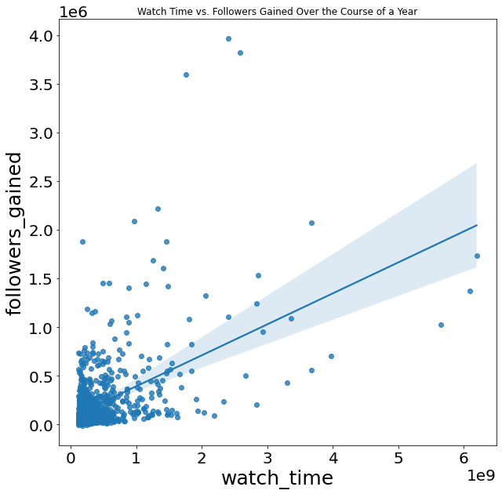

```python
plt.figure(figsize=(10,10))
plt.rc('xtick', labelsize=20)
plt.rc('ytick', labelsize=20)
plt.rc('axes', labelsize=25)
sns.regplot(x = "watch_time", y = "followers_gained", data = watch_followers_df).set(title="Watch Time vs. Followers Gained Over the Course of a Year")
plt.show()
```

As you can see, the line of best fit is more clear with these variables. There is a positive correlation between the watch time and number of followers gained.

```python
y = watch_followers_df['followers_gained']
x = watch_followers_df['watch_time']
x2 = sma.add_constant(x)
watch_follow_model = sma.OLS(y, x2).fit()
print(watch_follow_model.summary())
```

```
                            OLS Regression Results
==============================================================================
Dep. Variable:       followers_gained   R-squared:                       0.265
Model:                            OLS   Adj. R-squared:                  0.264
Method:                 Least Squares   F-statistic:                     359.6
Date:                Sat, 17 Dec 2022   Prob (F-statistic):           1.02e-68
Time:                        04:30:29   Log-Likelihood:                -14001.
No. Observations:                1000   AIC:                         2.801e+04
Df Residuals:                     998   BIC:                         2.802e+04
Df Model:                           1
Covariance Type:            nonrobust
==============================================================================
                 coef    std err          t      P>|t|      [0.025      0.975]
------------------------------------------------------------------------------
const       7.234e+04   1.16e+04      6.241      0.000    4.96e+04    9.51e+04
watch_time     0.0003   1.68e-05     18.962      0.000       0.000       0.000
==============================================================================
Omnibus:                     1012.530   Durbin-Watson:                   1.809
Prob(Omnibus):                  0.000   Jarque-Bera (JB):            64854.580
Skew:                           4.674   Prob(JB):                         0.00
Kurtosis:                      41.329   Cond. No.                     8.68e+08
==============================================================================

Notes:
[1] Standard Errors assume that the covariance matrix of the errors is correctly specified.
[2] The condition number is large, 8.68e+08. This might indicate that there are
strong multicollinearity or other numerical problems.
```

Next, we can calculate the p-value for these variables. The value is approximately 0 (<0.05), so we can reject the null hypothesis and state that there is a distinct correlation.

# By Language

Let’s retrieve the top 5 languages used amongst the top 1000 Twitch streamers:

```python
channel_count_by_language.head(5)
```

```
language
English    485
Korean      77
Russian     74
Spanish     68
French      66
Name: channel, dtype: int64
```

We can use the same calculations (for each of the 5 languages) that we did for the stream time vs. followers gained, as well as watch time vs. followers gained.

```python
top_languages = ["English", "Korean", "Russian", "Spanish", "French"]
top_languages
```

```
['English', 'Korean', 'Russian', 'Spanish', 'French']
```

By using regplot from the seaborn library, we can compare stream time vs. followers gained for each of these languages individually.

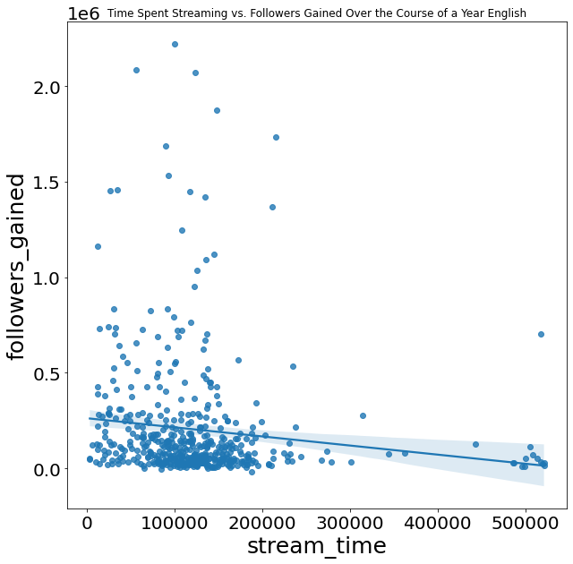

```
                            OLS Regression Results
==============================================================================
Dep. Variable:       followers_gained   R-squared:                       0.017
Model:                            OLS   Adj. R-squared:                  0.015
Method:                 Least Squares   F-statistic:                     8.122
Date:                Sat, 17 Dec 2022   Prob (F-statistic):            0.00456
Time:                        04:30:29   Log-Likelihood:                -6823.4
No. Observations:                 485   AIC:                         1.365e+04
Df Residuals:                     483   BIC:                         1.366e+04
Df Model:                           1
Covariance Type:            nonrobust
===============================================================================
                  coef    std err          t      P>|t|      [0.025      0.975]
-------------------------------------------------------------------------------
const        2.625e+05   2.52e+04     10.432      0.000    2.13e+05    3.12e+05
stream_time    -0.4760      0.167     -2.850      0.005      -0.804      -0.148
==============================================================================
Omnibus:                      379.395   Durbin-Watson:                   1.391
Prob(Omnibus):                  0.000   Jarque-Bera (JB):             5031.317
Skew:                           3.455   Prob(JB):                         0.00
Kurtosis:                      17.185   Cond. No.                     2.67e+05
==============================================================================

Notes:
[1] Standard Errors assume that the covariance matrix of the errors is correctly specified.
[2] The condition number is large, 2.67e+05. This might indicate that there are
strong multicollinearity or other numerical problems.
```

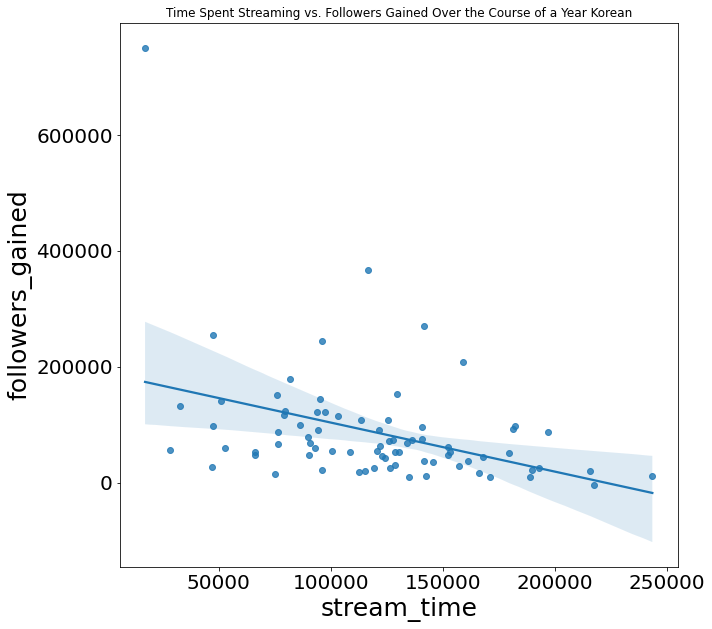

```
                            OLS Regression Results
==============================================================================
Dep. Variable:       followers_gained   R-squared:                       0.151
Model:                            OLS   Adj. R-squared:                  0.140
Method:                 Least Squares   F-statistic:                     13.38
Date:                Sat, 17 Dec 2022   Prob (F-statistic):           0.000470
Time:                        04:30:30   Log-Likelihood:                -989.80
No. Observations:                  77   AIC:                             1984.
Df Residuals:                      75   BIC:                             1988.
Df Model:                           1
Covariance Type:            nonrobust
===============================================================================
                  coef    std err          t      P>|t|      [0.025      0.975]
-------------------------------------------------------------------------------
const        1.882e+05   2.98e+04      6.326      0.000    1.29e+05    2.47e+05
stream_time    -0.8473      0.232     -3.658      0.000      -1.309      -0.386
==============================================================================
Omnibus:                       91.076   Durbin-Watson:                   1.743
Prob(Omnibus):                  0.000   Jarque-Bera (JB):             1241.377
Skew:                           3.615   Prob(JB):                    2.74e-270
Kurtosis:                      21.294   Cond. No.                     3.58e+05
==============================================================================

Notes:
[1] Standard Errors assume that the covariance matrix of the errors is correctly specified.
[2] The condition number is large, 3.58e+05. This might indicate that there are
strong multicollinearity or other numerical problems.
```

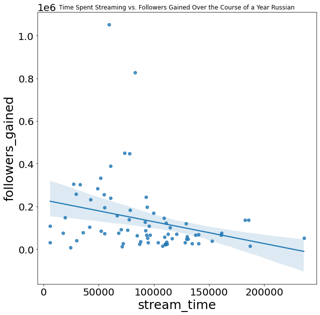

```
                            OLS Regression Results
==============================================================================
Dep. Variable:       followers_gained   R-squared:                       0.074
Model:                            OLS   Adj. R-squared:                  0.061
Method:                 Least Squares   F-statistic:                     5.772
Date:                Sat, 17 Dec 2022   Prob (F-statistic):             0.0189
Time:                        04:30:30   Log-Likelihood:                -993.01
No. Observations:                  74   AIC:                             1990.
Df Residuals:                      72   BIC:                             1995.
Df Model:                           1
Covariance Type:            nonrobust
===============================================================================
                  coef    std err          t      P>|t|      [0.025      0.975]
-------------------------------------------------------------------------------
const        2.301e+05   4.33e+04      5.314      0.000    1.44e+05    3.16e+05
stream_time    -1.0217      0.425     -2.402      0.019      -1.869      -0.174
==============================================================================
Omnibus:                       78.330   Durbin-Watson:                   1.574
Prob(Omnibus):                  0.000   Jarque-Bera (JB):              675.272
Skew:                           3.233   Prob(JB):                    2.33e-147
Kurtosis:                      16.312   Cond. No.                     2.30e+05
==============================================================================

Notes:
[1] Standard Errors assume that the covariance matrix of the errors is correctly specified.
[2] The condition number is large, 2.3e+05. This might indicate that there are
strong multicollinearity or other numerical problems.
```

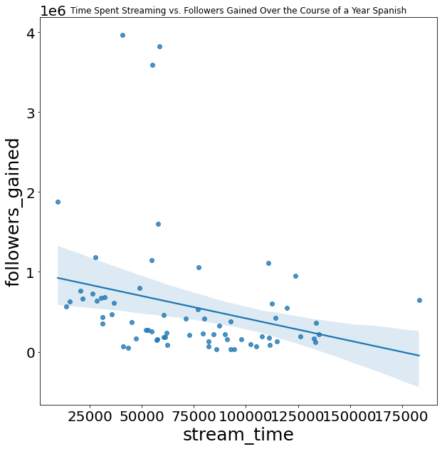

```
                            OLS Regression Results
==============================================================================
Dep. Variable:       followers_gained   R-squared:                       0.068
Model:                            OLS   Adj. R-squared:                  0.054
Method:                 Least Squares   F-statistic:                     4.820
Date:                Sat, 17 Dec 2022   Prob (F-statistic):             0.0317
Time:                        04:30:30   Log-Likelihood:                -1017.0
No. Observations:                  68   AIC:                             2038.
Df Residuals:                      66   BIC:                             2042.
Df Model:                           1
Covariance Type:            nonrobust
===============================================================================
                  coef    std err          t      P>|t|      [0.025      0.975]
-------------------------------------------------------------------------------
const        9.773e+05   2.07e+05      4.711      0.000    5.63e+05    1.39e+06
stream_time    -5.5946      2.548     -2.195      0.032     -10.682      -0.507
==============================================================================
Omnibus:                       67.290   Durbin-Watson:                   0.519
Prob(Omnibus):                  0.000   Jarque-Bera (JB):              375.026
Skew:                           3.066   Prob(JB):                     3.67e-82
Kurtosis:                      12.735   Cond. No.                     1.81e+05
==============================================================================

Notes:
[1] Standard Errors assume that the covariance matrix of the errors is correctly specified.
[2] The condition number is large, 1.81e+05. This might indicate that there are
strong multicollinearity or other numerical problems.
```

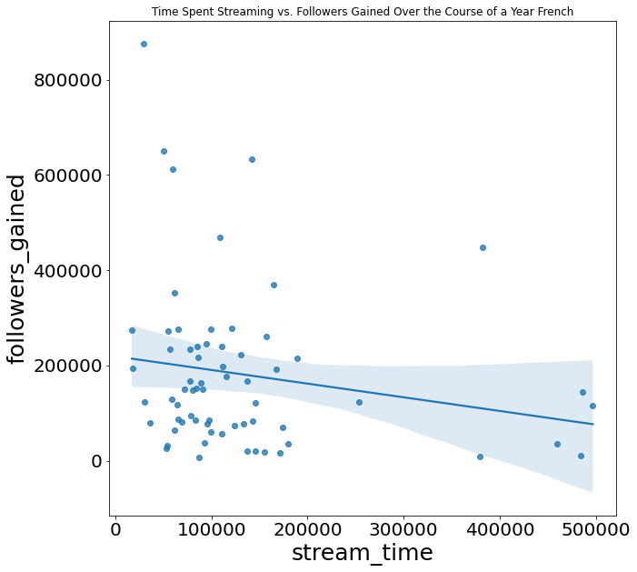

```
                            OLS Regression Results
==============================================================================
Dep. Variable:       followers_gained   R-squared:                       0.036
Model:                            OLS   Adj. R-squared:                  0.020
Method:                 Least Squares   F-statistic:                     2.356
Date:                Sat, 17 Dec 2022   Prob (F-statistic):              0.130
Time:                        04:30:31   Log-Likelihood:                -886.63
No. Observations:                  66   AIC:                             1777.
Df Residuals:                      64   BIC:                             1782.
Df Model:                           1
Covariance Type:            nonrobust
===============================================================================
                  coef    std err          t      P>|t|      [0.025      0.975]
-------------------------------------------------------------------------------
const        2.192e+05   3.21e+04      6.821      0.000    1.55e+05    2.83e+05
stream_time    -0.2868      0.187     -1.535      0.130      -0.660       0.086
==============================================================================
Omnibus:                       36.361   Durbin-Watson:                   1.552
Prob(Omnibus):                  0.000   Jarque-Bera (JB):               79.175
Skew:                           1.871   Prob(JB):                     6.42e-18
Kurtosis:                       6.846   Cond. No.                     2.68e+05
==============================================================================

Notes:
[1] Standard Errors assume that the covariance matrix of the errors is correctly specified.
[2] The condition number is large, 2.68e+05. This might indicate that there are
strong multicollinearity or other numerical problems.
```

```python
# Loop through each of the top five languages and create a linear regression plot and summary
for lang in top_languages:
    curr_df = df.loc[df['language'] == lang]
    plt.figure(figsize=(10,10))
    plt.rc('xtick', labelsize=20)
    plt.rc('ytick', labelsize=20)
    plt.rc('axes', labelsize=25)
    title_str = "Time Spent Streaming vs. Followers Gained Over the Course of a Year " + lang
    sns.regplot(x = "stream_time", y = "followers_gained", data = curr_df).set(title= title_str)
    plt.show()
    y = curr_df['followers_gained']
    x = curr_df['stream_time']
    x2 = sma.add_constant(x)
    watch_follow_model = sma.OLS(y, x2).fit()
    print(watch_follow_model.summary())
```

Each group has a negative linear regression line and most have a stream time p-value that is less than 0.05, meaning that the null hypothesis can be rejected for most. However, the p-value for the French language is 0.13, greather than 0.05. This means that we must accept the null hypothesis that there is no correlation between time spent streaming and followers gained. Some things that could have affected this are that there was less data in the French language group, as it was the fifth most popular language, and that there were quite a few outliers in the data.

Now, let's see look at the watch times vs followers gained for each of these languages.

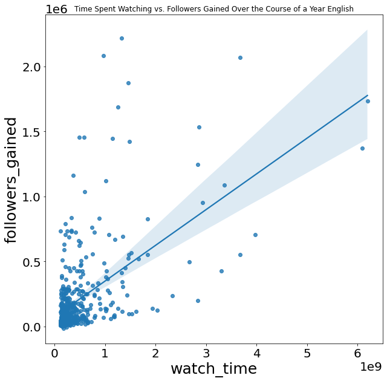

```
                            OLS Regression Results
==============================================================================
Dep. Variable:       followers_gained   R-squared:                       0.323
Model:                            OLS   Adj. R-squared:                  0.322
Method:                 Least Squares   F-statistic:                     230.8
Date:                Sat, 17 Dec 2022   Prob (F-statistic):           7.00e-43
Time:                        04:30:31   Log-Likelihood:                -6732.7
No. Observations:                 485   AIC:                         1.347e+04
Df Residuals:                     483   BIC:                         1.348e+04
Df Model:                           1
Covariance Type:            nonrobust
==============================================================================
                 coef    std err          t      P>|t|      [0.025      0.975]
------------------------------------------------------------------------------
const       7.355e+04   1.45e+04      5.058      0.000     4.5e+04    1.02e+05
watch_time     0.0003   1.81e-05     15.190      0.000       0.000       0.000
==============================================================================
Omnibus:                      355.600   Durbin-Watson:                   2.162
Prob(Omnibus):                  0.000   Jarque-Bera (JB):             5007.709
Skew:                           3.106   Prob(JB):                         0.00
Kurtosis:                      17.464   Cond. No.                     9.93e+08
==============================================================================

Notes:
[1] Standard Errors assume that the covariance matrix of the errors is correctly specified.
[2] The condition number is large, 9.93e+08. This might indicate that there are
strong multicollinearity or other numerical problems.
```

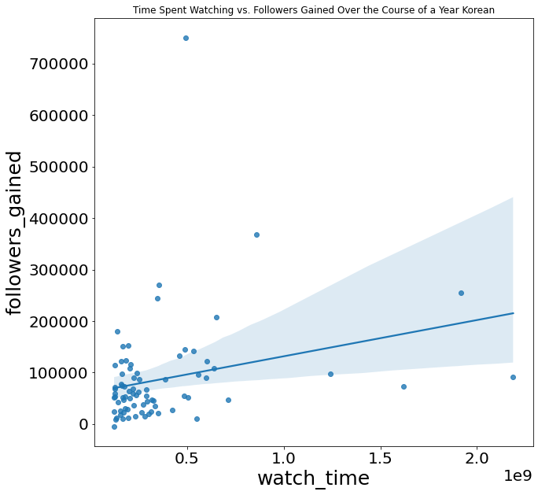

```
                            OLS Regression Results
==============================================================================
Dep. Variable:       followers_gained   R-squared:                       0.067
Model:                            OLS   Adj. R-squared:                  0.055
Method:                 Least Squares   F-statistic:                     5.405
Date:                Sat, 17 Dec 2022   Prob (F-statistic):             0.0228
Time:                        04:30:31   Log-Likelihood:                -993.44
No. Observations:                  77   AIC:                             1991.
Df Residuals:                      75   BIC:                             1996.
Df Model:                           1
Covariance Type:            nonrobust
==============================================================================
                 coef    std err          t      P>|t|      [0.025      0.975]
------------------------------------------------------------------------------
const       6.122e+04   1.57e+04      3.911      0.000       3e+04    9.24e+04
watch_time  7.042e-05   3.03e-05      2.325      0.023    1.01e-05       0.000
==============================================================================
Omnibus:                      105.163   Durbin-Watson:                   2.197
Prob(Omnibus):                  0.000   Jarque-Bera (JB):             2214.126
Skew:                           4.282   Prob(JB):                         0.00
Kurtosis:                      27.835   Cond. No.                     7.22e+08
==============================================================================

Notes:
[1] Standard Errors assume that the covariance matrix of the errors is correctly specified.
[2] The condition number is large, 7.22e+08. This might indicate that there are
strong multicollinearity or other numerical problems.
```

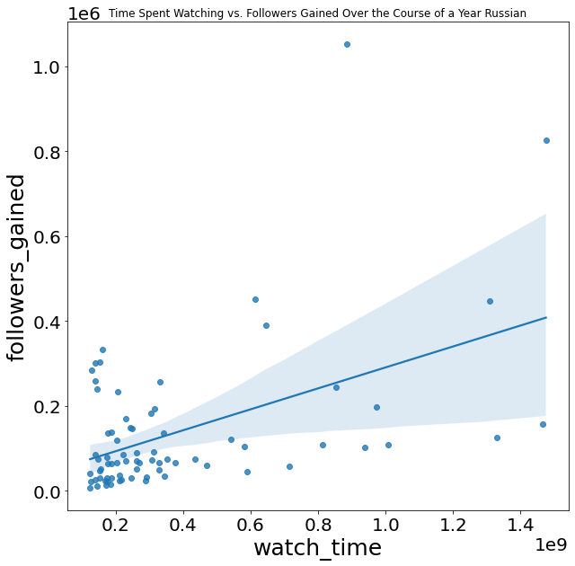

```
                            OLS Regression Results
==============================================================================
Dep. Variable:       followers_gained   R-squared:                       0.229
Model:                            OLS   Adj. R-squared:                  0.218
Method:                 Least Squares   F-statistic:                     21.39
Date:                Sat, 17 Dec 2022   Prob (F-statistic):           1.61e-05
Time:                        04:30:32   Log-Likelihood:                -986.24
No. Observations:                  74   AIC:                             1976.
Df Residuals:                      72   BIC:                             1981.
Df Model:                           1
Covariance Type:            nonrobust
==============================================================================
                 coef    std err          t      P>|t|      [0.025      0.975]
------------------------------------------------------------------------------
const       4.405e+04   2.66e+04      1.654      0.102   -9032.942    9.71e+04
watch_time     0.0002   5.33e-05      4.625      0.000       0.000       0.000
==============================================================================
Omnibus:                       60.726   Durbin-Watson:                   2.095
Prob(Omnibus):                  0.000   Jarque-Bera (JB):              351.144
Skew:                           2.432   Prob(JB):                     5.63e-77
Kurtosis:                      12.499   Cond. No.                     7.59e+08
==============================================================================

Notes:
[1] Standard Errors assume that the covariance matrix of the errors is correctly specified.
[2] The condition number is large, 7.59e+08. This might indicate that there are
strong multicollinearity or other numerical problems.
```

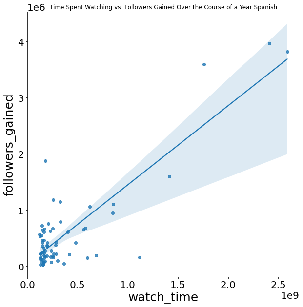

```
                            OLS Regression Results
==============================================================================
Dep. Variable:       followers_gained   R-squared:                       0.724
Model:                            OLS   Adj. R-squared:                  0.719
Method:                 Least Squares   F-statistic:                     172.7
Date:                Sat, 17 Dec 2022   Prob (F-statistic):           4.28e-20
Time:                        04:30:32   Log-Likelihood:                -975.71
No. Observations:                  68   AIC:                             1955.
Df Residuals:                      66   BIC:                             1960.
Df Model:                           1
Covariance Type:            nonrobust
==============================================================================
                 coef    std err          t      P>|t|      [0.025      0.975]
------------------------------------------------------------------------------
const       4.073e+04   6.48e+04      0.628      0.532   -8.87e+04     1.7e+05
watch_time     0.0014      0.000     13.143      0.000       0.001       0.002
==============================================================================
Omnibus:                       15.275   Durbin-Watson:                   1.902
Prob(Omnibus):                  0.000   Jarque-Bera (JB):               48.279
Skew:                           0.444   Prob(JB):                     3.28e-11
Kurtosis:                       7.031   Cond. No.                     7.73e+08
==============================================================================

Notes:
[1] Standard Errors assume that the covariance matrix of the errors is correctly specified.
[2] The condition number is large, 7.73e+08. This might indicate that there are
strong multicollinearity or other numerical problems.
```

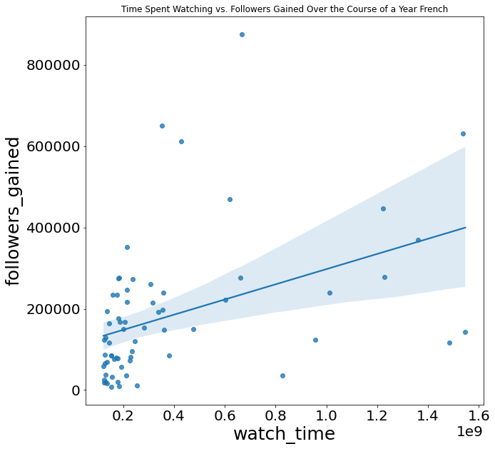

```
                            OLS Regression Results
==============================================================================
Dep. Variable:       followers_gained   R-squared:                       0.176
Model:                            OLS   Adj. R-squared:                  0.163
Method:                 Least Squares   F-statistic:                     13.65
Date:                Sat, 17 Dec 2022   Prob (F-statistic):           0.000459
Time:                        04:30:32   Log-Likelihood:                -881.45
No. Observations:                  66   AIC:                             1767.
Df Residuals:                      64   BIC:                             1771.
Df Model:                           1
Covariance Type:            nonrobust
==============================================================================
                 coef    std err          t      P>|t|      [0.025      0.975]
------------------------------------------------------------------------------
const       1.108e+05    2.7e+04      4.100      0.000    5.68e+04    1.65e+05
watch_time     0.0002   5.06e-05      3.694      0.000    8.58e-05       0.000
==============================================================================
Omnibus:                       36.520   Durbin-Watson:                   2.224
Prob(Omnibus):                  0.000   Jarque-Bera (JB):               93.690
Skew:                           1.750   Prob(JB):                     4.52e-21
Kurtosis:                       7.671   Cond. No.                     7.56e+08
==============================================================================

Notes:
[1] Standard Errors assume that the covariance matrix of the errors is correctly specified.
[2] The condition number is large, 7.56e+08. This might indicate that there are
strong multicollinearity or other numerical problems.
```

```python
# Loop through each of the top five languages and create a linear regression plot and summary
for lang in top_languages:
    curr_df = df.loc[df['language'] == lang]
    plt.figure(figsize=(10,10))
    plt.rc('xtick', labelsize=20)
    plt.rc('ytick', labelsize=20)
    plt.rc('axes', labelsize=25)
    title_str = "Time Spent Watching vs. Followers Gained Over the Course of a Year " + lang
    sns.regplot(x = "watch_time", y = "followers_gained", data = curr_df).set(title= title_str)
    plt.show()
    y = curr_df['followers_gained']
    x = curr_df['watch_time']
    x2 = sma.add_constant(x)
    watch_follow_model = sma.OLS(y, x2).fit()
    print(watch_follow_model.summary())
```

You can see a linear regression line with a positive correlation in all of these graphs, and all of the p-values that correspond with watch time are less than 0.05, meaning that the null hypothesis can be rejected in all of these groups.

## Communication of Insights Attained

### Streaming Times vs Followers Gained

Based on the plotted data and linear regression model, we can conclude that streaming for longer results in less followers gained (negative correlation). Channels like Riot Games and Asmongold, for example, are outliers in the scatter plot as they have gained a lot of followers with relatively low stream time. The opposite is true as well for channels like MarketTradersTV or jmjdoc, who had high stream times but low follower gain.

### What does this all mean?

This data may be helpful to people who want to become popular live streamers, as the information drawn from this tutorial shows what you can do to gain more followers. We know that the correlation between stream time and followers gained is negative, so that shows that it is not optimal to try and gain popularity on Twitch by just streaming a lot. What matters is that people watch the content, as they are more likely to follow and support streamers that produce good content. Overall, this tutorial has shown how the data science pipeline works through sets of data, so that we can better understand data science and the significance of relationships and observations.

### Helpful Online Resources

Here are some online resources that were helpful during the creation of this project:\ [pandas documentation](https://pandas.pydata.org/docs/) [matplotlib tutorials](https://matplotlib.org/stable/tutorials/index.html) [OLS Summary}(https://www.statsmodels.org/dev/generated/statsmodels.regression.linear_model.OLS.html)